# Predicting NBA Fan Support by Population Size

```r
popsize_model <- lm(Popularity ~ Size + factor(MonthNum):(W.L. + Playoffs)
                       ,na.action = na.exclude, data = NBATeams)
summary(popsize_model)
```

```
Call:
lm(formula = Popularity ~ Size + factor(MonthNum):(W.L. + Playoffs),
    data = NBATeams, na.action = na.exclude)

Residuals:
    Min      1Q  Median      3Q     Max
-26.167  -1.371  -0.325   0.680  69.529

Coefficients:
                                               Estimate Std. Error
(Intercept)                                  -3.913e+00  2.952e-01
Size                                          1.005e-06  5.518e-08
factor(MonthNum)1:W.L.                        1.110e+01  9.296e-01
factor(MonthNum)2:W.L.                        1.109e+01  9.296e-01
factor(MonthNum)3:W.L.                        1.053e+01  9.296e-01
factor(MonthNum)4:W.L.                        1.156e+01  9.296e-01
factor(MonthNum)5:W.L.                        1.309e+01  9.296e-01
factor(MonthNum)6:W.L.                        1.120e+01  9.296e-01
factor(MonthNum)7:W.L.                        9.686e+00  9.296e-01
factor(MonthNum)8:W.L.                        7.192e+00  9.296e-01
factor(MonthNum)9:W.L.                        6.938e+00  9.296e-01
factor(MonthNum)10:W.L.                       1.005e+01  9.296e-01
factor(MonthNum)11:W.L.                       1.144e+01  9.296e-01
factor(MonthNum)12:W.L.                       1.137e+01  9.296e-01
factor(MonthNum)1:PlayoffsLost 1st Round     -1.919e+00  5.692e-01
factor(MonthNum)2:PlayoffsLost 1st Round     -1.757e+00  5.692e-01
factor(MonthNum)3:PlayoffsLost 1st Round     -1.636e+00  5.692e-01
factor(MonthNum)4:PlayoffsLost 1st Round     -1.010e+00  5.692e-01
factor(MonthNum)5:PlayoffsLost 1st Round     -3.826e+00  5.692e-01
factor(MonthNum)6:PlayoffsLost 1st Round     -3.025e+00  5.692e-01
factor(MonthNum)7:PlayoffsLost 1st Round     -1.835e+00  5.692e-01
factor(MonthNum)8:PlayoffsLost 1st Round     -1.200e+00  5.692e-01
factor(MonthNum)9:PlayoffsLost 1st Round     -1.135e+00  5.692e-01
factor(MonthNum)10:PlayoffsLost 1st Round    -2.090e+00  5.692e-01
factor(MonthNum)11:PlayoffsLost 1st Round    -2.200e+00  5.692e-01
factor(MonthNum)12:PlayoffsLost 1st Round    -1.951e+00  5.692e-01
factor(MonthNum)1:PlayoffsLost Conf. Finals  -2.796e+00  9.317e-01
factor(MonthNum)2:PlayoffsLost Conf. Finals  -2.678e+00  9.317e-01
factor(MonthNum)3:PlayoffsLost Conf. Finals  -2.214e+00  9.317e-01
factor(MonthNum)4:PlayoffsLost Conf. Finals  -1.337e+00  9.317e-01
```

[output cut: 111 more lines]

```
factor(MonthNum)5:PlayoffsWon Finals           7.667 2.13e-14 ***
factor(MonthNum)6:PlayoffsWon Finals          21.685  < 2e-16 ***
factor(MonthNum)7:PlayoffsWon Finals          -0.894 0.371297
factor(MonthNum)8:PlayoffsWon Finals          -1.149 0.250578
factor(MonthNum)9:PlayoffsWon Finals          -1.054 0.291950
factor(MonthNum)10:PlayoffsWon Finals         -0.644 0.519627
factor(MonthNum)11:PlayoffsWon Finals          1.108 0.267703
factor(MonthNum)12:PlayoffsWon Finals          1.745 0.080995 .
---
Signif. codes:  0 ‘***’ 0.001 ‘**’ 0.01 ‘*’ 0.05 ‘.’ 0.1 ‘ ’ 1

Residual standard error: 4.032 on 4726 degrees of freedom
  (660 observations deleted due to missingness)
Multiple R-squared:   0.39, Adjusted R-squared:  0.3806
F-statistic: 41.39 on 73 and 4726 DF,  p-value: < 2.2e-16
```

```r
NBATeams <- NBATeams %>% add_predictions(popsize_model, var = "pred_by_pop")
```

We decided to fit a linear model to predict popularity scores for all teams, using TV Market Size, Month, and the interactions between month of the year and Win/Loss percentage and month of the year and Playoff performance (which measures how far a team made it in the playoffs for a given year). We also fit a model that used Team instead of TV market size as a predictor, but we believe that this model is a better fit for a few reasons. When using the model with Team as a predictor, the model was using an average for each particular team in order to fit the predictions.

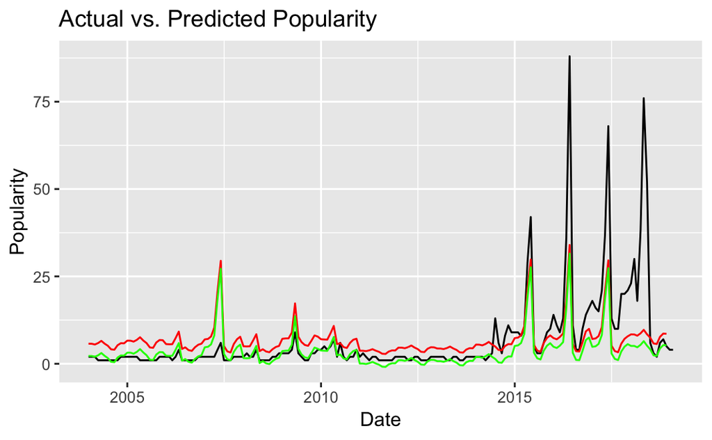

```r
NBATeams %>%
  filter(Team == "ClevelandCavaliers") %>%
  ggplot() + geom_line(aes(x = Date, y = Popularity)) + geom_line(aes(x = Date, y = pred), col = "red") + geom_line(aes(x = Date, y = pred_by_pop), col = "green")+
  ggtitle("Actual vs. Predicted Popularity")
```

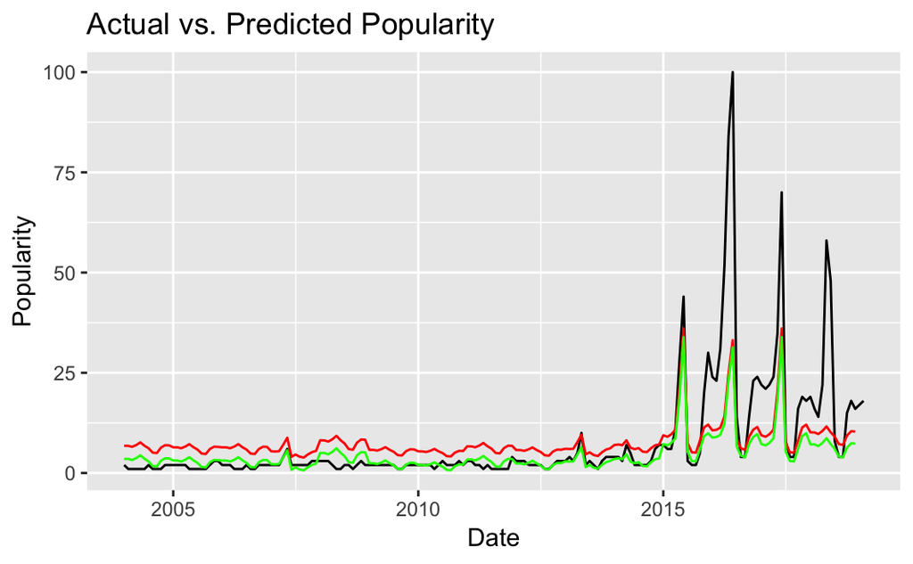

```r
NBATeams %>%
  filter(Team == "GoldenStateWarriors") %>%
  ggplot() + geom_line(aes(x = Date, y = Popularity)) + geom_line(aes(x = Date, y = pred), col = "red") + geom_line(aes(x = Date, y = pred_by_pop), col = "green")+
  ggtitle("Actual vs. Predicted Popularity")
```

One issue that we had to correct for with this model is the fact that there are 2 teams that share a TV Market. The Los Angeles Lakers and Clippers share a market (as well as an arena), and the Brooklyn Nets and New York Knicks share a TV market as well. In order to quantify each of these 4 team’s respective market share, I referred to the Nielsen Ratings for these teams.

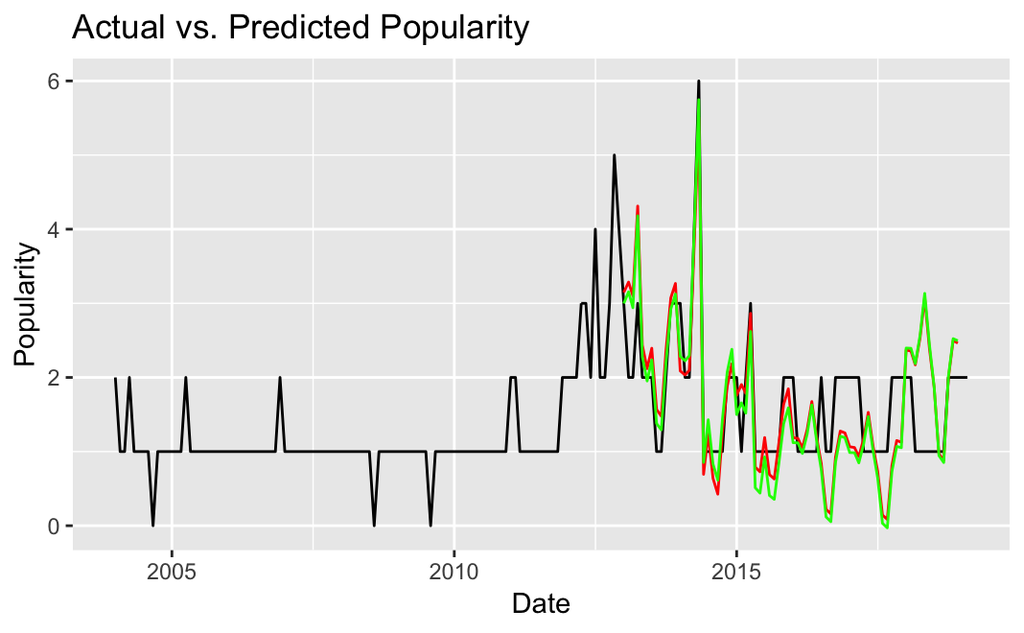

```r
NBATeams %>%
  filter(Team == "BrooklynNets") %>%
  ggplot() + geom_line(aes(x = Date, y = Popularity)) + geom_line(aes(x = Date, y = pred), col = "red") + geom_line(aes(x = Date, y = pred_by_pop), col = "green")+
  ggtitle("Actual vs. Predicted Popularity")
```

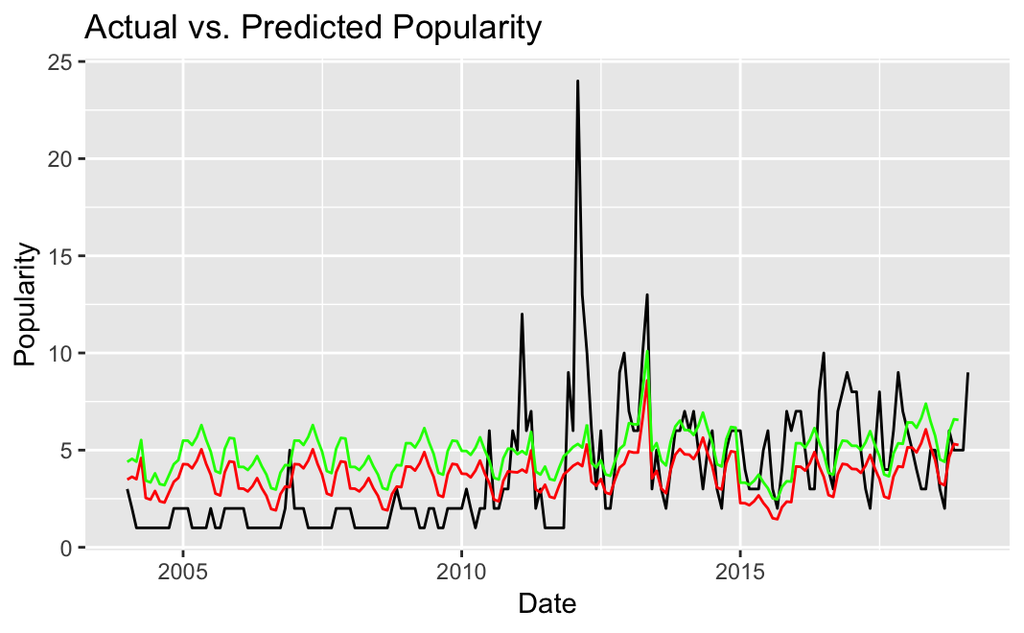

```r
NBATeams %>%
  filter(Team == "NewYorkKnicks") %>%
  ggplot() + geom_line(aes(x = Date, y = Popularity)) + geom_line(aes(x = Date, y = pred), col = "red") + geom_line(aes(x = Date, y = pred_by_pop), col = "green")+
  ggtitle("Actual vs. Predicted Popularity")
```

```r
Summerpops <- NBATeams %>%
  group_by(Team) %>%
  filter(!is.na(Popularity)) %>%
  filter(!is.na(pred_by_pop)) %>%
  filter(month(Date) < 10 &  month(Date) > 6) %>%
  summarize(SummerPopDiff = mean(Popularity - pred_by_pop))

t.test(Summerpops$SummerPopDiff)
```

```
    One Sample t-test

data:  Summerpops$SummerPopDiff
t = 1.0391, df = 28, p-value = 0.3076
alternative hypothesis: true mean is not equal to 0
95 percent confidence interval:
 -0.1503913  0.4600661
sample estimates:
mean of x
0.1548374
```

[figure not shown]

```r
NBATeams %>%
  filter(!is.na(Popularity)) %>%
  filter(!is.na(pred_by_pop)) %>%
  filter(month(Date) < 10 &  month(Date) > 6) %>%
  mutate(diff = Popularity - pred_by_pop) %>%
  ggplot(aes(x = Team, y = diff)) + geom_boxplot()
```

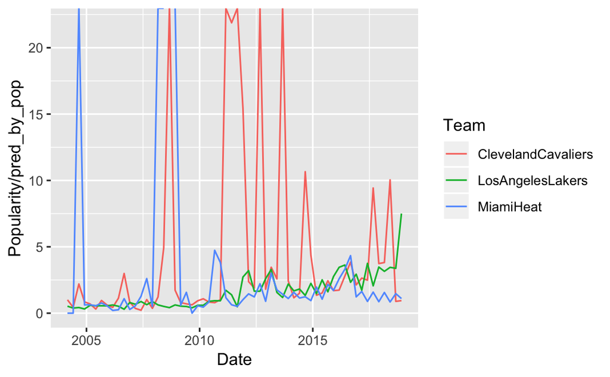

```r
NBATeams %>%
  filter(Team == c("ClevelandCavaliers", "LosAngelesLakers", "MiamiHeat")) %>%
  ggplot(aes(x = Date, y = Popularity/pred_by_pop, color = Team)) + geom_line()
```

## negative predictions to 0

## make final dataset that reads in properly

## side by side to justify Nielsen adjustment

```r
sum(NBATeams$pred_by_pop > 0)
```

```
[1] NA
```

```r
arrange(BW_Ratio$BWScoreRatio)
```

[output not shown]

[figure not shown]

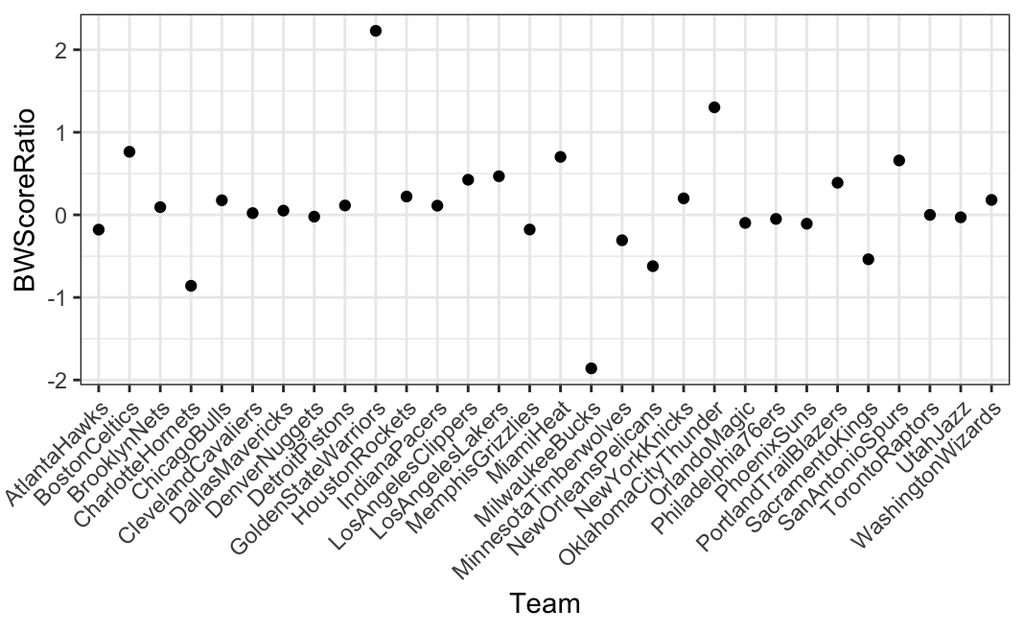

```r
ggplot(BW_Ratio, aes(x = Team, y = BWScoreRatio, fill = Team)) + geom_point() + theme(axis.text.x=element_text(angle=45, hjust=1)) +
  guides(fill = FALSE)
```

```r
NA
```

```r
library(gganimate)
library(gifski)
library(png)
theme_set(theme_bw())

p <- NBATeams %>%
  filter(Team == c("ClevelandCavaliers", "LosAngelesLakers", "MiamiHeat")) %>%
  ggplot(aes(x = Date, y = Popularity, color = Team)) + geom_line() + ylim(0,100)

p + transition_reveal(Date)
```

[output not shown]

[output cut: 46 more lines]

[output not shown]

[figure not shown]

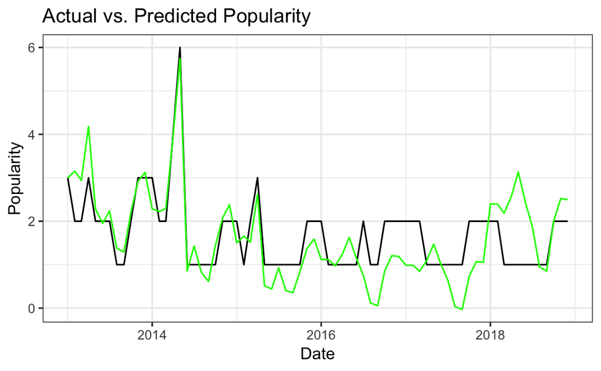

```r
#Nielsen Adjustment
NBATeams %>%
  filter(Team == "BrooklynNets" & Date %within% interval("2013-01-01", "2018-12-01")) %>%
  ggplot() + geom_line(aes(x = Date, y = Popularity)) + geom_line(aes(x = Date, y = pred_by_pop), col = "green")+
  ggtitle("Actual vs. Predicted Popularity")
```

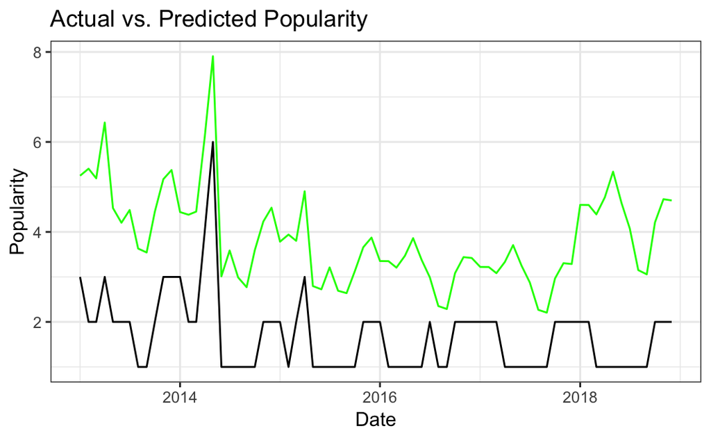

```r
#Without Nielsen Adjustment
NBA_Unadj <- read_csv("./NBATeams_Nielsen_Unadj.csv")
NBA_Unadj %>%
  filter(Team == "BrooklynNets" & Date %within% interval("2013-01-01", "2018-12-01")) %>%
  ggplot() + geom_line(aes(x = Date, y = Popularity)) + geom_line(aes(x = Date, y = pred_by_pop), col = "green")+
  ggtitle("Actual vs. Predicted Popularity")
```

```r
NA
NA
```

Here, we are comparing the fits of the predicted popularity scores against the observerd popularity scores for the Brooklyn Nets between 2013 and 2018 (because the Nets relocated to Brooklyn in 2013). The first graph shows the comparison of the predicted values, using the adjusted Nielsen values where Brooklyn is given roughly 30% of the New York Market share (instead of the previous full market share).

The second plot shows the predicted popularity scores against the observed the popularity scores, without the adjustment for the shared New York City market with the New York Knicks. In this model, we can see that since the Brooklyn Nets are being allotted the entire New York City market share, the model is greatly overpredicting popularity scores for the Nets throughout all time points.

Thus, we proceeded with the corrected Nielsen population size for the Brooklyn Nets, where they are receiving 30% of the New York City market share.

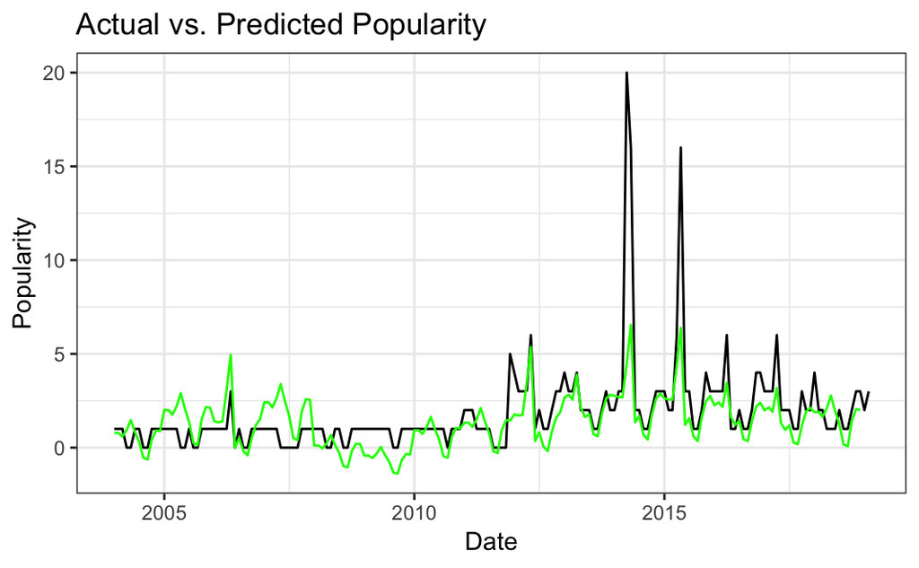

```r
NBATeams %>%
  filter(Team == "LosAngelesClippers") %>%
  ggplot() + geom_line(aes(x = Date, y = Popularity)) + geom_line(aes(x = Date, y = pred_by_pop), col = "green")+
  ggtitle("Actual vs. Predicted Popularity")
```

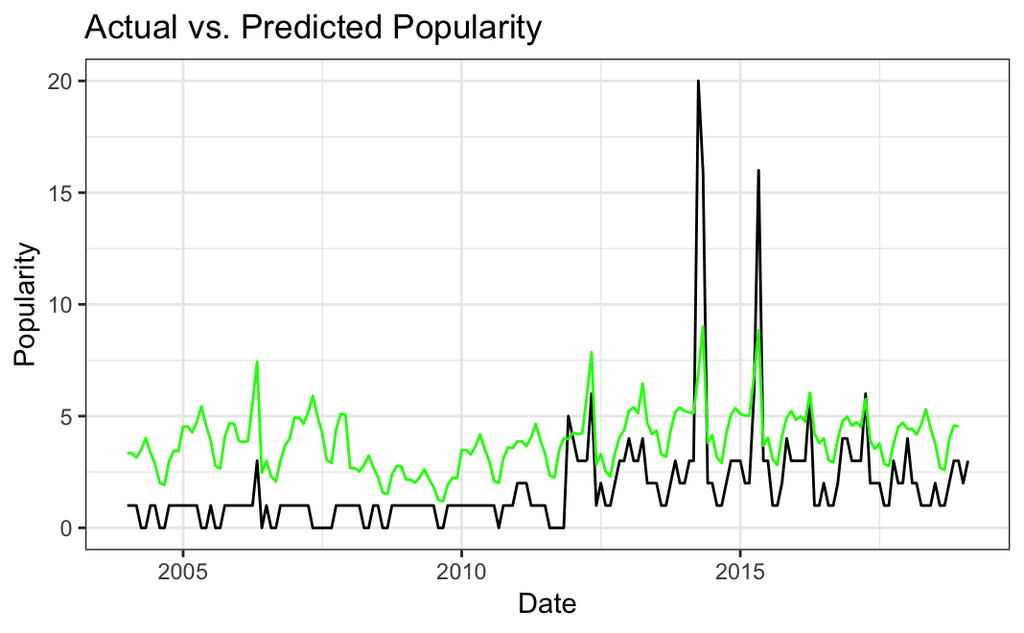

```r
#Without Nielsen Adjustment
#NBA_Unadj <- read_csv("./NBATeams_Nielsen_Unadj.csv")

NBA_Unadj %>%
  filter(Team == "LosAngelesClippers") %>%
  ggplot() + geom_line(aes(x = Date, y = Popularity)) + geom_line(aes(x = Date, y = pred_by_pop), col = "green")+
  ggtitle("Actual vs. Predicted Popularity")
```

We also see similar results when viewing the predicted popularity scores for the Los Angeles Clippers. After adjusting the Nielsen population size, we see that the model is also no longer overpredicting the popularity scores for the Clippers.

#Creating Clean Final Datset

```r
names(NBATeams)
```

```
 [1] "Date"          "Team"          "Popularity"    "MonthNum"
 [5] "pred"          "Season"        "Lg"            "W"
 [9] "L"             "W.L."          "Finish"        "SRS"
[13] "Pace"          "Rel_Pace"      "ORtg"          "Rel_ORtg"
[17] "DRtg"          "Rel_DRtg"      "Playoffs"      "Coaches"
[21] "Top WS"        "IndPlayoffs"   "PO_diff"       "NP_diff"
[25] "Bandwagon"     "Market"        "Size"          "pred_by_pop"
[29] "diff"          "Succ_Cat"      "DarkHorseDiff" "FavoriteDiff"
[33] "ContenderDiff" "BWScore"
```